# Analysis of data on physical activity using Machine Learning techniques.

Debsubhra Roy

## Background

Using devices such as Jawbone Up, Nike FuelBand, and Fitbit it is now possible to collect a large amount of data about personal activity relatively inexpensively. These type of devices are part of the quantified self movement – a group of enthusiasts who take measurements about themselves regularly to improve their health, to find patterns in their behavior, or because they are tech geeks. One thing that people regularly do is quantify how much of a particular activity they do, but they rarely quantify how well they do it. In this project, your goal will be to use data from accelerometers on the belt, forearm, arm, and dumbell of 6 participants. They were asked to perform barbell lifts correctly and incorrectly in 5 different ways. More information is available from the website here: http://groupware.les.inf.puc-rio.br/har (see the section on the Weight Lifting Exercise Dataset).

## Data

The data for the training set is available at: https://d396qusza40orc.cloudfront.net/predmachlearn/pml-training.csv

The data for the test is available at: https://d396qusza40orc.cloudfront.net/predmachlearn/pml-testing.csv

Download the datasets

```r
loadcsvdata <- function(url, nastrings) {
    temp <- tempfile()
    download.file(url, temp, method = "curl")
    data <- read.csv(temp, na.string = nastrings)
    unlink(temp)
    return(data)
}

trainurl <- "https://d396qusza40orc.cloudfront.net/predmachlearn/pml-training.csv"
train <- loadcsvdata(trainurl, c("", "NA", "#DIV/0!"))

testurl <- "https://d396qusza40orc.cloudfront.net/predmachlearn/pml-testing.csv"
test <- loadcsvdata(testurl, c("", "NA", "#DIV/0!"))

#train <- train[,-c(1:7)]
#test <- test[,-c(1:7)]

dim(train)
```

```
## [1] 19622   160
```

```r
colnames(train)
```

```
##   [1] "X"                        "user_name"
##   [3] "raw_timestamp_part_1"     "raw_timestamp_part_2"
##   [5] "cvtd_timestamp"           "new_window"
##   [7] "num_window"               "roll_belt"
##   [9] "pitch_belt"               "yaw_belt"
##  [11] "total_accel_belt"         "kurtosis_roll_belt"
##  [13] "kurtosis_picth_belt"      "kurtosis_yaw_belt"
##  [15] "skewness_roll_belt"       "skewness_roll_belt.1"
##  [17] "skewness_yaw_belt"        "max_roll_belt"
##  [19] "max_picth_belt"           "max_yaw_belt"
##  [21] "min_roll_belt"            "min_pitch_belt"
##  [23] "min_yaw_belt"             "amplitude_roll_belt"
##  [25] "amplitude_pitch_belt"     "amplitude_yaw_belt"
##  [27] "var_total_accel_belt"     "avg_roll_belt"
##  [29] "stddev_roll_belt"         "var_roll_belt"
```

[output cut: 65 more lines]

```r
table(train$classe)
```

```
##
##    A    B    C    D    E
## 5580 3797 3422 3216 3607
```

## Preprocessing of the data

We will partition the data using R caret package into training and validation set.

```r
library(caret)
set.seed(369)
trainingSet <- createDataPartition(train$class, p=0.8, list=FALSE)
training <- train[trainingSet,]
validation <- train[-trainingSet,]
```

### Feature selection

```r
# exclude near zero variance features
nzvcol <- nearZeroVar(training)

# exclude columns with missing & null values and descriptive values
cntlength <- sapply(training, function(x) {
    sum(!(is.na(x) | x == ""))
})

nullcol <- names(cntlength[cntlength < 0.6 * length(training$classe)])
descriptcol <- c("X", "user_name", "raw_timestamp_part_1", "raw_timestamp_part_2",
    "cvtd_timestamp", "new_window", "num_window")
excludecols <- c(descriptcol, nullcol)
training <- training[, !names(training) %in% excludecols]
```

## Model the training samples

We will use random forest technique to model the training samples.

```r
library(randomForest)
rfModel <- randomForest(classe ~ ., data = training, importance = TRUE, ntrees = 300)

print(rfModel)
```

```
##
## Call:
##  randomForest(formula = classe ~ ., data = training, importance = TRUE,      ntrees = 300)
##                Type of random forest: classification
##                      Number of trees: 500
## No. of variables tried at each split: 7
##
##         OOB estimate of  error rate: 0.45%
## Confusion matrix:
##      A    B    C    D    E  class.error
## A 4462    2    0    0    0 0.0004480287
## B   14 3014   10    0    0 0.0078999342
## C    0   12 2725    1    0 0.0047479912
## D    0    0   24 2548    1 0.0097162845
## E    0    0    2    4 2880 0.0020790021
```

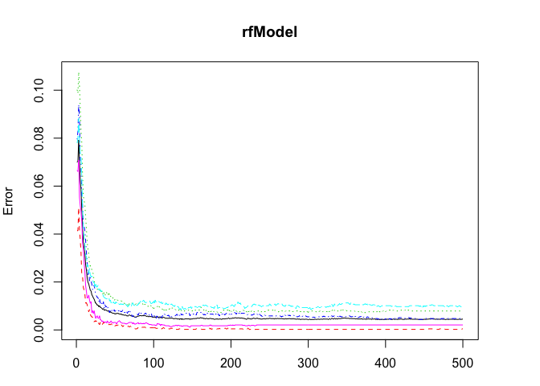

```r
par(mar=c(3,4,4,4))
plot(rfModel)
```

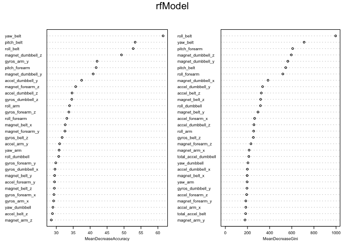

```r
varImpPlot(rfModel,cex=.5)
```

## Model Validation

We will test our model performance on the training samples and the cross validation samples.

### Training set accuracy

```r
ptraining <- predict(rfModel, training)
print(confusionMatrix(ptraining, training$classe))
```

```
## Confusion Matrix and Statistics
##
##           Reference
## Prediction    A    B    C    D    E
##          A 4464    0    0    0    0
##          B    0 3038    0    0    0
##          C    0    0 2738    0    0
##          D    0    0    0 2573    0
##          E    0    0    0    0 2886
##
## Overall Statistics
##
##                Accuracy : 1
##                  95% CI : (0.9998, 1)
##     No Information Rate : 0.2843
##     P-Value [Acc > NIR] : < 2.2e-16
##
##                   Kappa : 1
##  Mcnemar's Test P-Value : NA
##
## Statistics by Class:
##
##                      Class: A Class: B Class: C Class: D Class: E
## Sensitivity            1.0000   1.0000   1.0000   1.0000   1.0000
## Specificity            1.0000   1.0000   1.0000   1.0000   1.0000
## Pos Pred Value         1.0000   1.0000   1.0000   1.0000   1.0000
## Neg Pred Value         1.0000   1.0000   1.0000   1.0000   1.0000
## Prevalence             0.2843   0.1935   0.1744   0.1639   0.1838
## Detection Rate         0.2843   0.1935   0.1744   0.1639   0.1838
## Detection Prevalence   0.2843   0.1935   0.1744   0.1639   0.1838
## Balanced Accuracy      1.0000   1.0000   1.0000   1.0000   1.0000
```

### Validation set accuracy

Check for prediction accuracy on cross validation samples.

```r
pvalidation <- predict(rfModel, validation)
print(confusionMatrix(pvalidation, validation$classe))
```

```
## Confusion Matrix and Statistics
##
##           Reference
## Prediction    A    B    C    D    E
##          A 1116    4    0    0    0
##          B    0  755    7    0    0
##          C    0    0  677    8    0
##          D    0    0    0  632    1
##          E    0    0    0    3  720
##
## Overall Statistics
##
##                Accuracy : 0.9941
##                  95% CI : (0.9912, 0.9963)
##     No Information Rate : 0.2845
##     P-Value [Acc > NIR] : < 2.2e-16
##
##                   Kappa : 0.9926
##  Mcnemar's Test P-Value : NA
##
## Statistics by Class:
##
##                      Class: A Class: B Class: C Class: D Class: E
## Sensitivity            1.0000   0.9947   0.9898   0.9829   0.9986
## Specificity            0.9986   0.9978   0.9975   0.9997   0.9991
## Pos Pred Value         0.9964   0.9908   0.9883   0.9984   0.9959
## Neg Pred Value         1.0000   0.9987   0.9978   0.9967   0.9997
## Prevalence             0.2845   0.1935   0.1744   0.1639   0.1838
## Detection Rate         0.2845   0.1925   0.1726   0.1611   0.1835
## Detection Prevalence   0.2855   0.1942   0.1746   0.1614   0.1843
## Balanced Accuracy      0.9993   0.9963   0.9936   0.9913   0.9988
```

```r
#validation$classe
```

The cross validation accuracy is 99.41% and the out-of-sample error is therefore 0.59% so our model performs quite good.

## Test sample prediction

```r
ptest <- predict(rfModel, test)
ptest
```

```
##  1  2  3  4  5  6  7  8  9 10 11 12 13 14 15 16 17 18 19 20
##  B  A  B  A  A  E  D  B  A  A  B  C  B  A  E  E  A  B  B  B
## Levels: A B C D E
```

### Save the output to the files

```r
answers <- as.vector(ptest)

pml_write_files = function(x) {
    n = length(x)
    for (i in 1:n) {
        filename = paste0("problem_id_", i, ".txt")
        write.table(x[i], file = filename, quote = FALSE, row.names = FALSE,
            col.names = FALSE)
    }
}

pml_write_files(answers)
```